# 361 - RECITATION 3

GENERATING RANDOM VARIATES

Remember that there are some techniques to generate random sample (numbers) from a distribution which are;

– Inverse transform method √

– Acceptance-rejection method

– Convolution method

– Composition method

We cannot use inverse transform method distributions which do not have closed from of CDF like normal, gamma, beta, etc. In such a cases we can use **Acceptance-rejection method**.

## Acceptance-rejection method

For instance, if one wants to generate 100 random numbers that belong to a normal distribution in R, it is as simple as executing:

```r
rnorm(100)
```

However, how does this process actually work under the algorithm? How can an algorithm know whether a random number belongs to a particular distribution or not?

The answer is through rejection sampling.

Acceptance-Rejection sampling is a way to simulate random samples from an **unknown** or **difficult to sample** from distribution by using random samples from a similar probability distribution. A random subset of the generated samples are rejected; the rest are accepted. The goal is for the accepted samples to be distributed as if they were from the unknown probability distribution.

### How Rejection Sampling Works

Assume that we have a random variable x, which has density function f(x). We want to generate data from this density function f(x).

To do this find an alternative probability distribution G, with density function g(x), from which we already have an efficient algorithm for generating from, but also such that the function g(x) is “close” to f(x). Then, we assume that the ratio $\frac{f(x)}{g(x)}$ is bounded by a constant c > 0.

$$\frac{f(x)}{g(x)} \leq c$$

To generate data from f(x); (we should follow the steps below)

1. Choose a density g(y) that is easy to sample from. (This density function is optional)
2. Find a constant c such that $\frac{f(x)}{g(x)} \leq c$.
3. Generate a random variable Y distributed as G(Y).
4. Generate a uniform random number U.
5. 5. If $U \leq \frac{f(x)}{g(x)*c}$ then accept set Y=X, else reject and go to step 3.

Note that;

$$c= max\left(\frac{f(x)}{g(x)}\right)$$
We can find a maximum x point that maximize the f(x), by taking derivative and equalize it to 0.

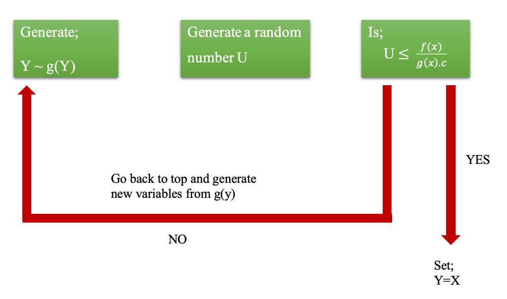

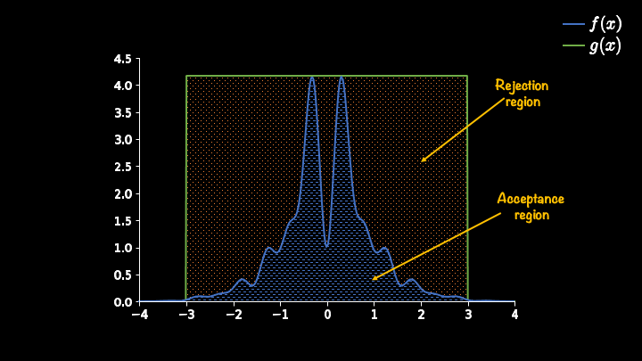

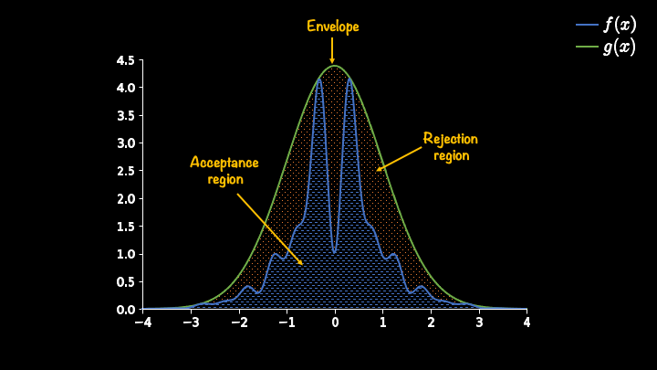

## Continuous Case

### Q1)

Create an algorithm (function) to generate data from the density function below.

The function is:

$$f(x) = 100x^3(1-x)^2,\ 0 \leq x \leq 1$$

$$g(x) = 1,\ 0 \leq x \leq 1.$$

After creating sample from that beta distribution, estimate $P(0 \leq X \leq 0.8)$ with k = 1000 repetitions (n=1000).

Let applied the procedure,

**1. We choose density g(x)=1, $0 \leq x \leq 1$**

**2. Find constant c;**

$$c= max\left(\frac{f(x)}{g(x)}\right)$$

$$\frac{d}{dx}\frac{f(x)}{g(x)} =0$$

$$\frac{d}{dx}\frac{100x^3(1-x)^2}{1}=0$$

$$100(5x^4-8x^3+3x^2)=0$$

Finally,

$$x=0,\ x=1\ and\ x=\frac{3}{5}$$
D ecide which x value maximize $\frac{d}{dx}\frac{f(x)}{g(x)}$.

When $x=\frac{3}{5}$, $\frac{d}{dx}\frac{f(x)}{g(x)}=\frac{432}{125}=3.5$.

That is why **c=3.5** is chosen.

**3. Generate a random variable Y distributed as G(Y). —–> g(x)=1 which is standard uniform.**

**4. Generate a uniform random number U. —–> u= runif(1)**

**5. If $U \leq \frac{100x^3(1-x)^2}{1*3.5}$ then accept set Y=X, else reject and go to step 3.**

```r
beta.rejection <- function(f, c, g, n) {
  set.seed(2022)
  k <- 0 # counter for accepted
  i <- 0 # number of iteration
  s <- c() #newly created random sample


  while (k < n) {
    x <- runif(1)
    i <- i+1
    u <- runif(1)

    if (u <= f(x) / (c*g(x))) {
      k <- k + 1
      s[k] = x

    }

  }
  print(summary(s))
  return(s)

}


f <- function(x) 100*(x^3)*(1-x)^2
g <- function(x) 1
c <- 3.5 # an upper bound for f(x)/g(x)


prob.result <- beta.rejection(f, c, g, n=1000)
```

```
##    Min. 1st Qu.  Median    Mean 3rd Qu.    Max.
## 0.09818 0.44099 0.58905 0.57391 0.70535 0.98020
```

```r
print(length(prob.result[prob.result <= 0.8])/1000)
```

```
## [1] 0.9
```

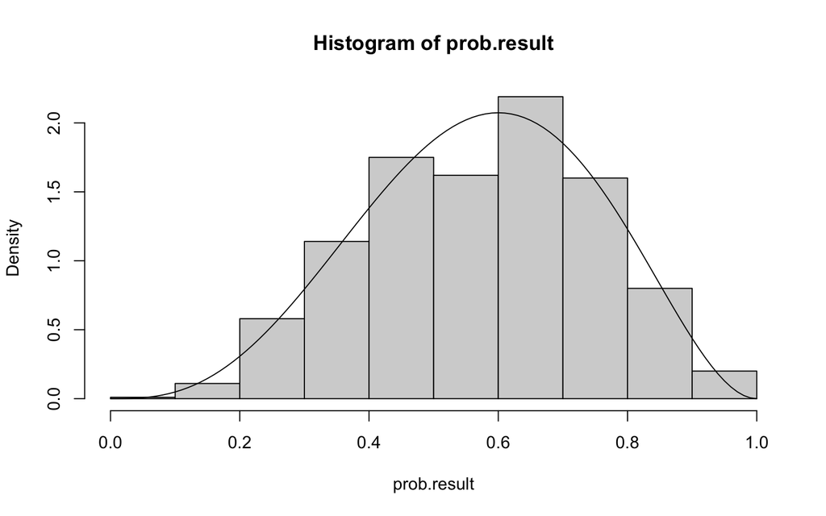

```r
hist(prob.result,freq = FALSE)
points(seq(0,1,0.01), dbeta(seq(0,1,0.01),4,3),type = "l")
```

### Q2)

Write a function which is generated a random variable from

$$f(x)= \frac{x^2}{18},\ -3 \leq x \leq 3$$
using acceptance – rejection method and generate n=10000 random samples.

Assume that $g(x)=1,0 \leq x \leq1$

Let applied the procedure,

**1. We choose density g(x)=1, $0 \leq x \leq 1$**

**2. Find constant c;**

$$c= max\left(\frac{f(x)}{g(x)}\right)$$

$$\frac{d}{dx}\frac{f(x)}{g(x)} =0$$
$$\frac{d}{dx}\frac{x^2}{18*1}=0$$

$$\frac{2x}{18*1}=0$$

$$x=0$$

When x=0, f(x) is also 0. In this way we cannot find maximum point. However, by putting x=3 which is maximum value that x can take, we can find maximum value of f(x). Thus, when x=3, $\frac{f(x)}{g(x)}=\frac{1}{2}$

That is why **c=0.5** is chosen.

**3. Generate a random variable Y distributed as G(Y). —–> g(x)=1 which is standard uniform**.

**4. Generate a uniform random number U. —–> u= runif(1)**

5. **If $U \leq \frac{x^2}{18*1*0.5}$ then accept set Y=X, else reject and go to step 3**.

```r
set.seed(2022)  # for reproducibility
n = 10^4        # sample size
i <- 0  # number of iteration
k <- 0 # counter for accepted
y <- numeric(n) # random sample

while (k < n) {
  u = runif(1)
  i <- i+1
  x = runif(1, -3,3)
  if (u <= x^2/(18*1*0.5)) {
    k <- k + 1
    y[k] <- x
  }
}
i;k;length(y)
```

```
## [1] 30244
```

```
## [1] 10000
```

```
## [1] 10000
```

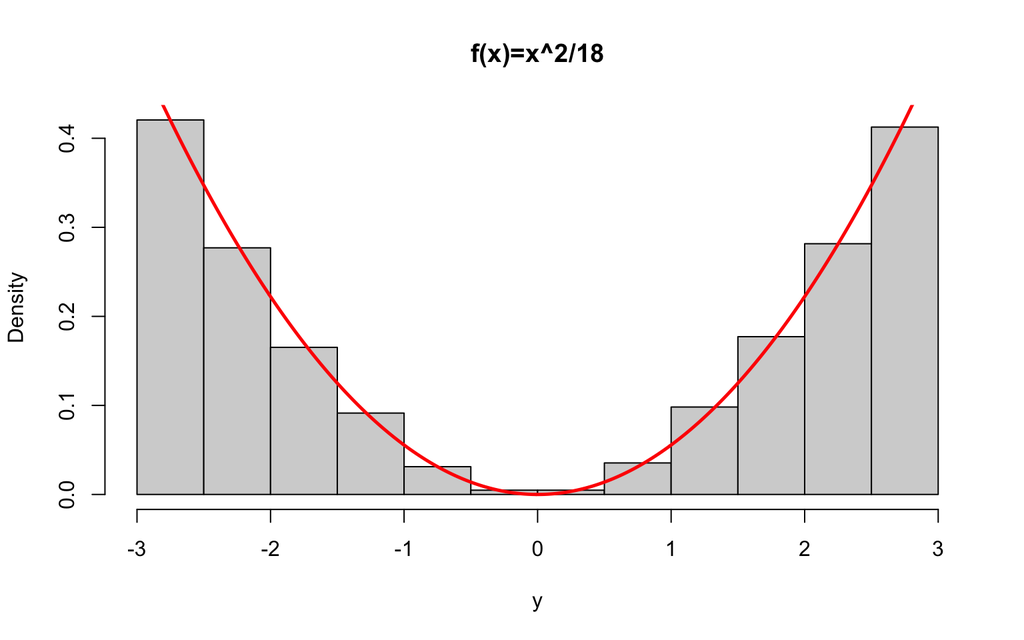

```r
hist(y, prob = TRUE, main ="f(x)=x^2/18")
a = seq(-3,3,0.01)
lines(a,a^2/18,col="red",lwd = 2.5)
```

```r
summary(y)
```

```
##     Min.  1st Qu.   Median     Mean  3rd Qu.     Max.
## -2.99960 -2.38161  0.60966  0.01376  2.37344  2.99960
```

We can write the code also without while loop;

```r
set.seed(1234)
n = 100000
x = runif(n, -3, 3)
u = runif(n)
# acceptance condition
s = x[u <= x^2/18]
length(s)
```

```
## [1] 16659
```

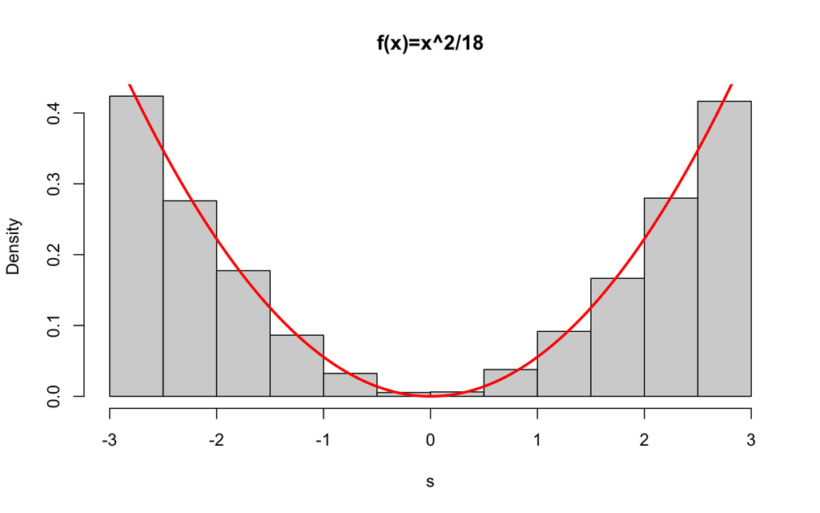

```r
hist(s, prob = TRUE, main ="f(x)=x^2/18")
a = seq(-3,3,0.01)
lines(a,a^2/18,col="red",lwd = 2.5)
```

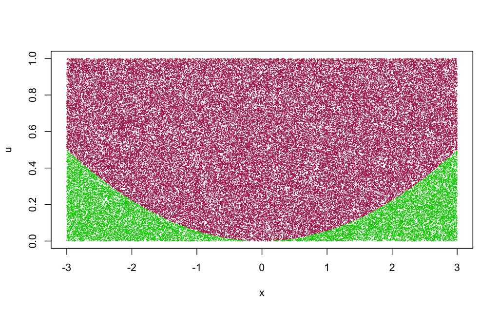

```r
plot(x,u, pch=".", col="maroon")
points(s,u[u <= x^2/18], pch=".", col="green3")
```

### Q3)

**Reminding!**

$$x \sim Exp(\lambda) =Gamma(1, \lambda)$$

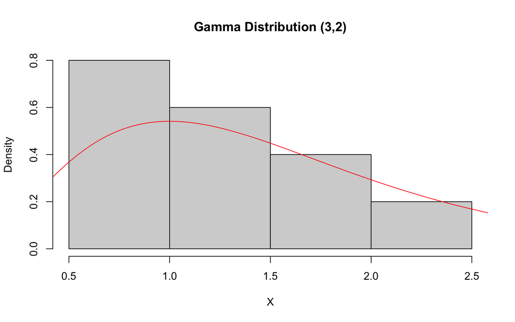

```r
set.seed(361)

gamma <- function(n,t,lambda) {
  U = matrix(runif(n*t),t, n)
  logU = -log(U) / lambda # exponential rv by using inverse transform method
  X = colSums(logU) # column sums of matrix logU
  hist(X, prob=TRUE, main ="Gamma Distribution (3,2)")
  y = seq(0,6,0.01)
  lines(y,dgamma(y,3,2),col="red") # theoritical curve for gamma dist.

}

n = 10
t = 3
lambda = 2

gamma(n,t,lambda)
```

## Discrete Case

Now, suppose we want to generate an X that is a discrete random variable with probability mass function(PMF) p(k)=P(X=k). Further suppose that we can easily generate a discrete random variable Y with PMF q(k)=P(Y=k) such that $\frac{p(k)}{q(k)} \leq c$.

- Step 1: Generate a random variable Y which is distributed as q(k).
- Step 2: Generate U (independent from Y).
- Step 3: If $u \leq \frac{p(k)}{q(k)*c}$, then set X = Y; otherwise go back to step 1.

### Q4)

Simulate a discrete random variable X that has PMF given by;

$$P(X=1)= 0.12$$

$$P(X=2)= 0.23$$

$$P(X=3)= 0.18$$

$$P(X=4)= 0.37$$

$$P(X=5)=0.07$$

$$P(X=6)=0.03$$

Lets apply the procedure above.

**Step 1: Generate a random variable Y which is distributed as q(k).**

Since the domain of X is 1, 2, 3, 4, 5, 6 we can assume that random variable Y has discrete uniform distribution between (1,6). The PMF of discrete uniform distribution is

$$q(k)=P(Y=k)= \frac{1}{6},\ k=1,2,3,4,5,6$$

**Step 2: Generate U (independent from Y). —> runif(1)**

**Step 3: If $u \leq \frac{p(k)}{q(k)*c}$, then set X = Y; otherwise go back to step 1.**

Firstly find minimum value of c value by finding maximum value of pmf p(k).

$$\frac{p(k)}{q(k)} \leq c$$

Since the biggest pmf for X is 0.37, we can choose minimum c by the equation:

$$\frac{max(p_x)}{0.1666667}=\frac{0.37}{0.1666667}=c=2.219$$

$$u \leq \frac{p(k)}{q(k)*c}$$

$$u \leq \frac{p(k)}{1/6*2.219}$$

```r
n <- 10000 # sample size
probs <- c(0.12, 0.23, 0.18, 0.37, 0.07, 0.03) # probabilities for desired density
c <- 2.219 #finded "c" value above
cq <- c * (1/6)
cq
```

```
## [1] 0.3698333
```

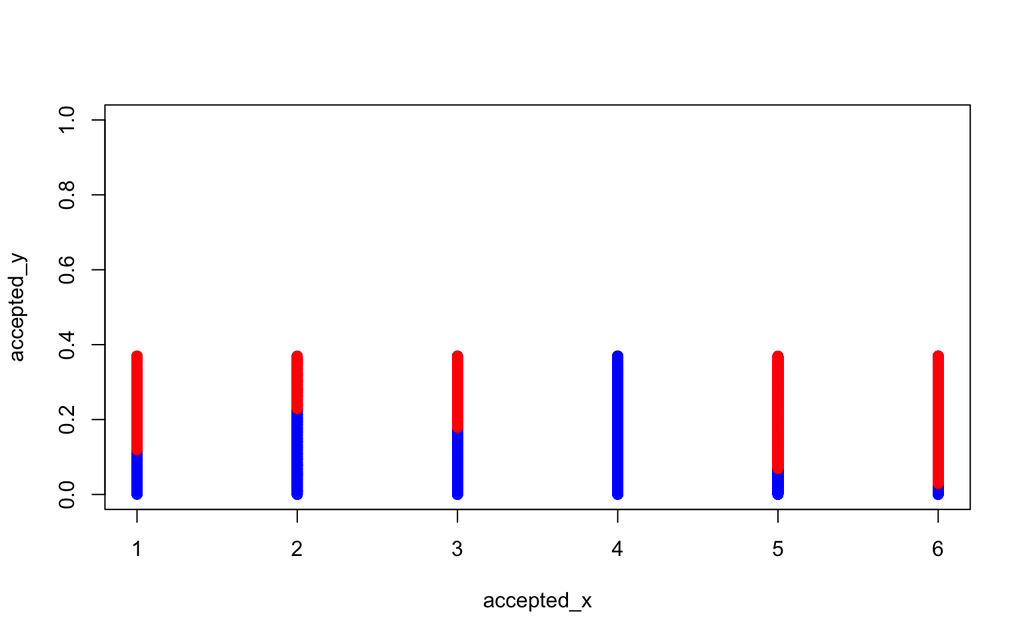

```r
# for accepted variates
accepted_x <- numeric(n)
accepted_y <- numeric(n)

# for rejected variates
rejected_x <- numeric(n)
rejected_y <- numeric(n)

i <- 1 # initialization of index for accepted r.v’s
j <- 1 # initialization of index for rejected r.v’s


set.seed(2022)

while(i <= n){

  k <- sample(1:6, size = 1) # random number for q(k)
  u <- runif(1) # random number for comparison
  cq <- 0.3698333
  if (u <= probs[k]/cq){
    accepted_x[i] <- k
    accepted_y[i] <- u * cq
    i <- i + 1
    }else{
      rejected_x[j] <- k
      rejected_y[j] <- u * cq
      j <- j + 1
    }
  }
plot(accepted_x, accepted_y, type="p", col="blue",ylim=c(0,1))
points(rejected_x, rejected_y,col="red")
```

```r
table(accepted_x)/n
```

```
## accepted_x
##      1      2      3      4      5      6
## 0.1219 0.2254 0.1859 0.3667 0.0716 0.0285
```

```r
x<- c(1,2,3,4,5,6)
theoretical_probabilities <- c(0.12, 0.23, 0.18, 0.37, 0.07, 0.03)
estimated_probabilities <- c(0.1219, 0.2254, 0.1859, 0.3667, 0.0716, 0.0285)
d<- data.frame(x,theoretical_probabilities,estimated_probabilities)
```

```r
library(dplyr)
library(kableExtra)
kbl(d) %>%
  kable_classic("striped", full_width = T) %>%
  column_spec(1, bold = T, background = "salmon")
```

| x | theoretical_probabilities | estimated_probabilities |
| --- | --- | --- |
| 1 | 0.12 | 0.1219 |
| 2 | 0.23 | 0.2254 |
| 3 | 0.18 | 0.1859 |
| 4 | 0.37 | 0.3667 |
| 5 | 0.07 | 0.0716 |
| 6 | 0.03 | 0.0285 |